# The Two-Stage Prediction Model for Individualized Treatment Benefit Behind the *Collaborative Care Compass*

- Show All Code
- Hide All Code
- View Source

Stage 2: CNMA Assumption Checks

Author

Affiliations

[DSSGx Munich 2026 Fellows](https://www.dssgxmunich.org/project-2026)

[Social Data Science and AI Lab, LMU Munich](https://www.stat.lmu.de/soda/en/)

[Munich Center for Machine Learning](https://mcml.ai/)

Published

October 6, 2026

Companion to the primary Stage-2 report, which shows the treatment network and component contrast matrix. These checks follow the additive-CNMA framework of [Rücker, Schmitz, and Schwarzer](https://doi.org/10.1002/bimj.201900339).

No component-by-component interaction terms are fitted. Global additivity is checked with

$$Q_{\mathrm{add}}
=
\left(\mathbf d-\mathbf X\widehat{\boldsymbol\beta}\right)^{\!\mathsf T}
\mathbf W
\left(\mathbf d-\mathbf X\widehat{\boldsymbol\beta}\right).$$

## 1. Setup and trial contrasts

Import the same cohort used by notebook 09.5, encode the 10 components, and calculate each study’s intervention-minus-control PHQ-9 contrast.

```python
%matplotlib inline

import json
from pathlib import Path

import matplotlib.pyplot as plt
import numpy as np
import pandas as pd
from scipy.stats import chi2

from collaborative_care_analysis.data_analysis.stage2_inputs import (
    create_path_cnma_cohort,
    load_stage1_risk_scores,
)


def find_project_root(start=Path.cwd()):
    for candidate in (start, *start.parents):
        if (candidate / "pyproject.toml").exists() and (candidate / "data").exists():
            return candidate
    raise FileNotFoundError("Run this report from inside the DSSGX CODE project.")


PROJECT_ROOT = find_project_root()
ENRICHED_PATH = (
    PROJECT_ROOT / "data" / "interim" / "enriched_dataset" / "enriched_dataset.csv"
)
RISK_MODEL_PATH = PROJECT_ROOT / "models" / "risk_score_model.rds"
RISK_MODEL_SCRIPT_PATH = (
    PROJECT_ROOT
    / "collaborative_care_analysis"
    / "data_analysis"
    / "risk_score_model.R"
)
RISK_MODEL_DATA_PATH = (
    PROJECT_ROOT
    / "data"
    / "processed"
    / "analysis_datasets"
    / "phq9_12mo_core"
    / "wide.csv"
)
EXPORT_DIR = PROJECT_ROOT / "reports" / "exports" / "path_cnma_assumption_checks"

FOLLOW_UP_WINDOW = (11.5, 12.5)
EXCLUDED_STUDIES = {"08_Coventry_2015"}
RANDOMIZED_ARMS = {"control", "intervention"}

pd.set_option("display.max_columns", 40)
pd.set_option("display.width", 180)
```

```
2026-10-06 17:24:57.175 | INFO     | collaborative_care_analysis.config:<module>:12 - PROJ_ROOT path is: /Users/jan/Work/LMU/dssg-2026/collaborative-care-analysis
```

**What this cell does.** Loads the libraries, imports the shared Stage-2 input functions, and locates the Stage-1 model and cohort used by the primary report.

**How to interpret the result.** No output is expected. A missing-file error means that the Stage-1 model or its analysis cohort must be built before running Stage 2.

```python
COMPONENT_SOURCES = {
    "specialist_involvement": [
        "treatment_supervising_psychiatrist_psychologist_was_involved",
        "treatment_cotreating_between_psychiatrist_and_psychologist_was_done",
    ],
    "psychological_treatment": [
        "treatment_counseling_was_provided_in_addition_to_medication_(≤ 8 sessions)",
        "treatment_manual_based_psychotherapy",
    ],
    "goal_setting": ["treatment_treatment_goals_were_considered"],
    "patient_preference": ["treatment_patient_preference_was_considered_in_treatment_decisions"],
    "automated_follow_up": ["treatment_automated_follow_up_process_was_used"],
    "regular_patient_review": ["treatment_regular_patient_review_was_scheduled"],
    "coping_strategies": ["treatment_are_disease_coping_strategies_taught"],
    "relapse_prevention": ["treatment_is_there_a_relapse_prevention_plan"],
    "family_involvement": ["treatment_were_family_and_friends_involved"],
    "community_cultural_bg": ["treatment_community_cultural_bg"],
}

COMPONENT_LABELS = {
    "specialist_involvement": "Specialist involvement",
    "psychological_treatment": "Psychological treatment",
    "goal_setting": "Goal setting",
    "patient_preference": "Patient preference considered",
    "automated_follow_up": "Automated follow-up",
    "regular_patient_review": "Regular patient review",
    "coping_strategies": "Coping strategies",
    "relapse_prevention": "Relapse prevention plan",
    "family_involvement": "Family and friends involved",
    "community_cultural_bg": "Community or cultural context",
}
component_cols = list(COMPONENT_SOURCES)
```

**What this cell does.** Defines the same 10 components and labels used in the fitted model.

**How to interpret the result.** No output is expected. Confirm that all 10 component names and labels are present before constructing the design matrix.

```python
risk_scores = load_stage1_risk_scores(
    RISK_MODEL_PATH,
    RISK_MODEL_SCRIPT_PATH,
    RISK_MODEL_DATA_PATH,
)

cohort, analysis_df = create_path_cnma_cohort(
    ENRICHED_PATH,
    risk_scores,
    follow_up_window=FOLLOW_UP_WINDOW,
    excluded_studies=EXCLUDED_STUDIES,
    randomized_arms=RANDOMIZED_ARMS,
)

patient_key = ["STUDY_ID", "patient_id"]
arm_keys = ["STUDY_ID", "study_arm"]

source_cols = sorted({column for columns in COMPONENT_SOURCES.values() for column in columns})
arm_keys = ["STUDY_ID", "study_arm"]
within_arm_variation = cohort.groupby(arm_keys)[source_cols].nunique(dropna=True)
if within_arm_variation.gt(1).any().any():
    raise ValueError("At least one component code varies within a study arm.")

arm_components_raw = cohort.groupby(arm_keys)[source_cols].first()
if arm_components_raw.isna().any().any():
    raise ValueError("At least one study arm has a missing component code.")

arm_components = pd.DataFrame(index=arm_components_raw.index)
for component, sources in COMPONENT_SOURCES.items():
    arm_components[component] = arm_components_raw[sources].eq("yes").max(axis=1).astype(int)

analysis_df = analysis_df.merge(
    arm_components.reset_index(), on=arm_keys, how="left", validate="many_to_one"
)
model_columns = [
    *patient_key,
    "study_arm",
    "age",
    "sex",
    "phq9_baseline",
    "phq9_12m",
    "outcome_month",
    "risk_score",
    *component_cols,
]
model_df = analysis_df[model_columns].dropna(subset=["phq9_12m", "risk_score", *component_cols]).copy()

assert len(model_df) == len(risk_scores), "Some patients with a Stage-1 risk score are missing from the model data."
assert model_df["STUDY_ID"].nunique() == 12
print(f"Analysis cohort: {len(model_df):,} patients in {model_df['STUDY_ID'].nunique()} studies")
```

```
Analysis cohort: 6,454 patients in 12 studies
```

**What this cell does.** Calls `create_path_cnma_cohort()`, applies the common component coding, and creates the complete-case diagnostic dataset.

**How to interpret the result.** The cohort should contain the intended studies and matched risk scores. Unexpected losses suggest missing outcomes, missing scores, or identifier mismatches.

```python
arm_packages = model_df.groupby(arm_keys)[component_cols].first()
X_contrast = (
    arm_packages.xs("intervention", level="study_arm")
    - arm_packages.xs("control", level="study_arm")
)

arm_outcomes = model_df.groupby(arm_keys)["phq9_12m"].agg(["mean", "var", "count"])
arm_mean = arm_outcomes["mean"].unstack("study_arm")
arm_var = arm_outcomes["var"].unstack("study_arm")
arm_n = arm_outcomes["count"].unstack("study_arm")

trial_contrasts = pd.DataFrame(index=X_contrast.index)
trial_contrasts["mean_difference"] = arm_mean["intervention"] - arm_mean["control"]
trial_contrasts["standard_error"] = np.sqrt(
    arm_var["intervention"] / arm_n["intervention"]
    + arm_var["control"] / arm_n["control"]
)
trial_contrasts["variance"] = trial_contrasts["standard_error"] ** 2
trial_contrasts["weight"] = 1 / trial_contrasts["variance"]

display(trial_contrasts.round(3), X_contrast)
```

| STUDY_ID | mean_difference | standard_error | variance | weight |
| --- | --- | --- | --- | --- |
| 02_Aragones_2012 | -1.632 | 0.818 | 0.669 | 1.494 |
| 04_Bekelman_2018 | -1.734 | 0.790 | 0.623 | 1.604 |
| 05_Bekelman_2015 | -0.923 | 0.995 | 0.991 | 1.010 |
| 10_Fletcher_2021a | -0.463 | 0.470 | 0.221 | 4.521 |
| 11_Fletcher_2021b | -0.608 | 0.357 | 0.127 | 7.850 |
| 12_Gensichen_2009 | 1.746 | 0.521 | 0.271 | 3.686 |
| 13_Hölzel_2018 | -0.890 | 0.652 | 0.425 | 2.352 |
| 22_Richards_2013 | -1.785 | 0.622 | 0.387 | 2.587 |
| 24_Rollman_2016 | -2.562 | 0.864 | 0.746 | 1.341 |
| 26_Salisbury_2016 | -0.290 | 0.565 | 0.319 | 3.132 |
| 30_Srinivasan_2022 | -1.002 | 0.127 | 0.016 | 61.545 |
| 33_Zimmerman_2016 | -0.504 | 0.840 | 0.706 | 1.416 |

| STUDY_ID | specialist_involvement | psychological_treatment | goal_setting | patient_preference | automated_follow_up | regular_patient_review | coping_strategies | relapse_prevention | family_involvement | community_cultural_bg |
| --- | --- | --- | --- | --- | --- | --- | --- | --- | --- | --- |
| 02_Aragones_2012 | 1 | 0 | 0 | 0 | 0 | 1 | 0 | 1 | 1 | 1 |
| 04_Bekelman_2018 | 0 | 1 | 1 | 1 | 0 | 1 | 1 | 0 | 1 | 0 |
| 05_Bekelman_2015 | 1 | 1 | 0 | 0 | 1 | 1 | 1 | 0 | 0 | 0 |
| 10_Fletcher_2021a | 1 | 0 | 1 | 1 | 1 | 1 | 1 | 0 | 0 | 1 |
| 11_Fletcher_2021b | 1 | 1 | 1 | 1 | 1 | 1 | 0 | 0 | 0 | 1 |
| 12_Gensichen_2009 | 0 | 1 | 1 | 0 | 1 | 1 | 1 | 0 | 0 | 0 |
| 13_Hölzel_2018 | 1 | 1 | 1 | 1 | 0 | 1 | 1 | 1 | 0 | 0 |
| 22_Richards_2013 | 1 | 1 | 0 | 0 | 0 | 1 | 1 | 1 | 0 | 0 |
| 24_Rollman_2016 | 1 | 1 | 1 | 1 | 1 | 1 | 1 | 0 | 0 | 1 |
| 26_Salisbury_2016 | 0 | 1 | 1 | 0 | 1 | 1 | 1 | 1 | 0 | 0 |
| 30_Srinivasan_2022 | 1 | 1 | 1 | 0 | 0 | 1 | 1 | 1 | 1 | 1 |
| 33_Zimmerman_2016 | 1 | 1 | 1 | 1 | 0 | 1 | 1 | 0 | 0 | 1 |

**What this cell does.** Calculates each study’s intervention-minus-control mean PHQ-9 difference, its standard error, and the corresponding component contrast row.

**How to interpret the result.** Each row represents one randomized study contrast. Negative mean differences favor intervention because lower PHQ-9 is better; matrix entries show which components differ between arms.

## 2. Global additivity

Fit the additive component design to the 12 trial contrasts. `Q` measures the outcome variation left unexplained after fitting the 10 component effects; a large value would indicate poor additive fit.

```python
def weighted_fit(design, outcome, weights):
    weighted_design = design * np.sqrt(weights[:, None])
    weighted_outcome = outcome * np.sqrt(weights)
    coefficients = np.linalg.lstsq(weighted_design, weighted_outcome, rcond=None)[0]
    fitted = design @ coefficients
    residuals = outcome - fitted
    rank = np.linalg.matrix_rank(design)
    q_value = float(np.sum(weights * residuals**2))
    degrees_of_freedom = len(outcome) - rank
    return {
        "coefficients": coefficients,
        "fitted": fitted,
        "residuals": residuals,
        "rank": rank,
        "Q": q_value,
        "df": degrees_of_freedom,
        "p_value": float(chi2.sf(q_value, degrees_of_freedom)),
    }


X = X_contrast.to_numpy(dtype=float)
d = trial_contrasts["mean_difference"].to_numpy()
weights = trial_contrasts["weight"].to_numpy()
additive = weighted_fit(X, d, weights)

additive_fit = pd.Series(
    {
        "comparisons": len(d),
        "components": X.shape[1],
        "rank": additive["rank"],
        "residual df": additive["df"],
        "Q": additive["Q"],
        "Q p-value": additive["p_value"],
        "weighted condition number": np.linalg.cond(X * np.sqrt(weights[:, None])),
    },
    name="value",
)
additive_fit.to_frame().round(3)
```

|  | value |
| --- | --- |
| comparisons | 12.000 |
| components | 10.000 |
| rank | 10.000 |
| residual df | 2.000 |
| Q | 0.229 |
| Q p-value | 0.892 |
| weighted condition number | 51.868 |

**What this cell does.** Fits the weighted additive component model to the 12 trial contrasts and calculates the residual Q statistic.

**How to interpret the result.** A small p-value indicates lack of additive fit. A large p-value means that lack of fit was not detected, but few residual degrees of freedom make this a low-power check rather than proof of additivity.

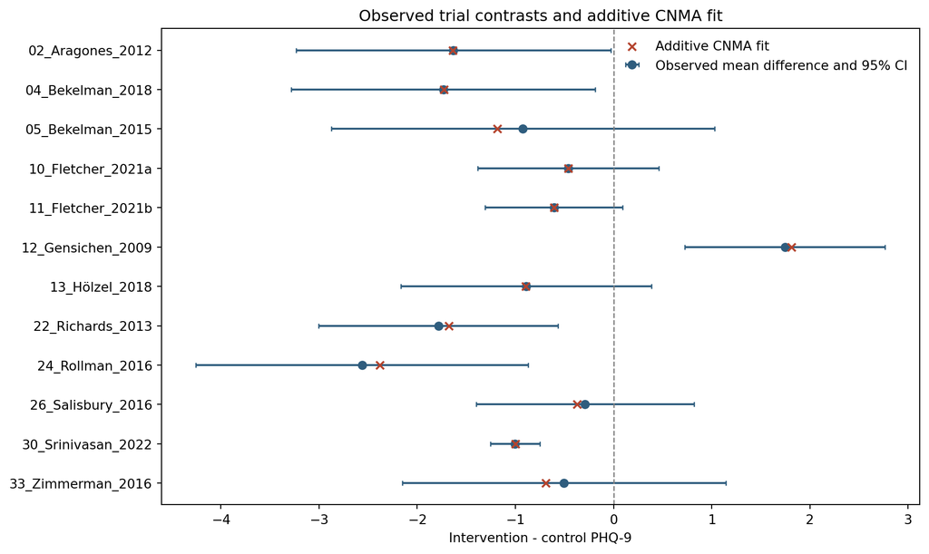

```python
contrast_fit = trial_contrasts.copy()
contrast_fit["fitted_additive"] = additive["fitted"]
contrast_fit["residual"] = additive["residuals"]
contrast_fit["Q_contribution"] = weights * additive["residuals"] ** 2

plot_data = contrast_fit.iloc[::-1]
y_positions = np.arange(len(plot_data))
fig, ax = plt.subplots(figsize=(10, 6))
ax.errorbar(
    plot_data["mean_difference"],
    y_positions,
    xerr=1.96 * plot_data["standard_error"],
    fmt="o",
    color="#2f5d7e",
    capsize=2,
    label="Observed mean difference and 95% CI",
)
ax.scatter(
    plot_data["fitted_additive"],
    y_positions,
    marker="x",
    color="#b4442e",
    label="Additive CNMA fit",
    zorder=3,
)
ax.axvline(0, color="0.5", linewidth=1, linestyle="--")
ax.set_yticks(y_positions, plot_data.index)
ax.set_xlabel("Intervention - control PHQ-9")
ax.set_title("Observed trial contrasts and additive CNMA fit")
ax.legend(frameon=False)
fig.tight_layout()
```

**What this cell does.** Plots each observed trial contrast against the value predicted by the additive component model.

## 3. Transitivity

Trials informing different components should be comparable in characteristics that could change treatment effects. Following [Cochrane guidance on transitivity](https://training.cochrane.org/handbook/current/chapter-11#section-11-2-2), compare component contrasts with baseline PHQ-9, age, sex composition, year, and Step-1 risk. Follow-up is fixed at 12 months; setting is unavailable.

```python
model_df["female"] = model_df["sex"].eq("Female").where(
    model_df["sex"].isin(["Female", "Male"])
)
trial_characteristics = model_df.groupby("STUDY_ID").agg(
    patients=("patient_id", "size"),
    mean_baseline_phq9=("phq9_baseline", "mean"),
    mean_age=("age", "mean"),
    female_proportion=("female", "mean"),
    mean_risk_score=("risk_score", "mean"),
    mean_followup_month=("outcome_month", "mean"),
)
trial_characteristics["publication_year"] = (
    trial_characteristics.index.to_series()
    .str.extract(r"_(\d{4})[A-Za-z]?$")[0]
    .astype(float)
    .to_numpy()
)

modifier_cols = [
    "mean_baseline_phq9",
    "mean_age",
    "female_proportion",
    "publication_year",
    "mean_risk_score",
]
trial_characteristics.round(3)
```

| STUDY_ID | patients | mean_baseline_phq9 | mean_age | female_proportion | mean_risk_score | mean_followup_month | publication_year |
| --- | --- | --- | --- | --- | --- | --- | --- |
| 02_Aragones_2012 | 302 | 17.748 | 48.440 | 0.811 | 1.154 | 12.0 | 2012.0 |
| 04_Bekelman_2018 | 217 | 9.396 | 65.913 | 0.161 | -0.322 | 12.0 | 2018.0 |
| 05_Bekelman_2015 | 134 | 14.366 | 63.813 | 0.030 | 0.559 | 12.0 | 2015.0 |
| 10_Fletcher_2021a | 823 | 11.564 | 42.948 | 0.719 | -0.019 | 12.0 | 2021.0 |
| 11_Fletcher_2021b | 1131 | 8.994 | 36.607 | 0.692 | -0.526 | 12.0 | 2021.0 |
| 12_Gensichen_2009 | 493 | 17.306 | 50.879 | 0.748 | 1.075 | 12.0 | 2009.0 |
| 13_Hölzel_2018 | 185 | 10.103 | 69.984 | 0.784 | -0.098 | 12.0 | 2018.0 |
| 22_Richards_2013 | 497 | 17.740 | 44.799 | 0.712 | 1.117 | 12.0 | 2013.0 |
| 24_Rollman_2016 | 228 | 14.509 | 45.294 | 0.741 | 0.514 | 12.0 | 2016.0 |
| 26_Salisbury_2016 | 497 | 16.751 | 51.861 | 0.686 | 0.957 | 12.0 | 2016.0 |
| 30_Srinivasan_2022 | 1769 | 8.193 | 59.233 | 0.751 | -0.563 | 12.0 | 2022.0 |
| 33_Zimmerman_2016 | 178 | 9.815 | 43.798 | 0.719 | -0.356 | 12.0 | 2016.0 |

**What this cell does.** Summarizes potential effect modifiers separately for each study.

**How to interpret the result.** Compare potential effect modifiers across studies and component exposures. Large systematic differences weaken the transitivity assumption.

|  |  | correlation |
| --- | --- | --- |
| mean_risk_score | patient_preference | -0.656 |
| mean_baseline_phq9 | patient_preference | -0.644 |

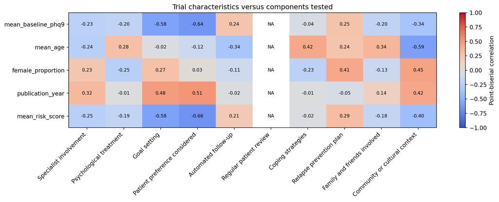

```python
transitivity_correlations = pd.DataFrame(
    index=modifier_cols, columns=component_cols, dtype=float
)
for modifier in modifier_cols:
    values = trial_characteristics.loc[X_contrast.index, modifier]
    for component in component_cols:
        tested = X_contrast[component].astype(float)
        if tested.nunique() > 1 and values.nunique() > 1:
            transitivity_correlations.loc[modifier, component] = np.corrcoef(
                values, tested
            )[0, 1]

transitivity_flags = (
    transitivity_correlations.stack()
    .rename("correlation")
    .loc[lambda values: values.abs() >= 0.60]
    .sort_values(key=abs, ascending=False)
    .to_frame()
)

fig, ax = plt.subplots(figsize=(13, 5))
heatmap = ax.imshow(
    transitivity_correlations.to_numpy(dtype=float),
    cmap="coolwarm",
    vmin=-1,
    vmax=1,
    aspect="auto",
)
ax.set_xticks(
    np.arange(len(component_cols)),
    [COMPONENT_LABELS[column] for column in component_cols],
    rotation=45,
    ha="right",
)
ax.set_yticks(np.arange(len(modifier_cols)), modifier_cols)
for row in range(len(modifier_cols)):
    for column in range(len(component_cols)):
        value = transitivity_correlations.iloc[row, column]
        label = "NA" if pd.isna(value) else f"{value:.2f}"
        ax.text(column, row, label, ha="center", va="center", fontsize=8)
fig.colorbar(heatmap, ax=ax, label="Point-biserial correlation")
ax.set_title("Trial characteristics versus components tested")
fig.tight_layout()

transitivity_flags.round(3)
```

**What this cell does.** Correlates trial characteristics with the component contrasts to screen for possible transitivity problems.

**How to interpret the result.** Large absolute correlations mean that a component is concentrated in studies with particular patient characteristics. Such flags suggest possible confounding of component effects with study case mix.

Two correlations exceed `|r|=0.60`: patient preference with baseline PHQ-9 (`r=-0.644`) and with risk (`r=-0.656`). This means the patient-preference comparison appears more often in lower-severity studies. It does not mean patient preference lowers baseline severity. These are descriptive flags from only 12 studies.

## 4. Identifiability

Full rank means the design contains enough distinct component patterns to estimate each component separately. The condition number checks whether those estimates may still be sensitive to small data changes.

```python
singular_values = np.linalg.svd(X * np.sqrt(weights[:, None]), compute_uv=False)
component_support = X_contrast.ne(0).sum().rename("trials testing component").to_frame()
component_support.index = component_support.index.map(COMPONENT_LABELS)

leave_one_out_rank = pd.Series(
    {
        study: np.linalg.matrix_rank(np.delete(X, index, axis=0))
        for index, study in enumerate(X_contrast.index)
    },
    name="rank after omission",
)

design_diagnostics = pd.Series(
    {
        "comparisons": X.shape[0],
        "component columns": X.shape[1],
        "rank": np.linalg.matrix_rank(X),
        "deficiency": X.shape[1] - np.linalg.matrix_rank(X),
        "unweighted condition number": np.linalg.cond(X),
        "weighted condition number": np.linalg.cond(X * np.sqrt(weights[:, None])),
        "minimum leave-one-study-out rank": leave_one_out_rank.min(),
    },
    name="value",
)

display(design_diagnostics.to_frame().round(3), component_support, leave_one_out_rank.to_frame())
```

|  | value |
| --- | --- |
| comparisons | 12.000 |
| component columns | 10.000 |
| rank | 10.000 |
| deficiency | 0.000 |
| unweighted condition number | 23.916 |
| weighted condition number | 51.868 |
| minimum leave-one-study-out rank | 10.000 |

|  | trials testing component |
| --- | --- |
| Specialist involvement | 9 |
| Psychological treatment | 10 |
| Goal setting | 9 |
| Patient preference considered | 6 |
| Automated follow-up | 6 |
| Regular patient review | 12 |
| Coping strategies | 10 |
| Relapse prevention plan | 5 |
| Family and friends involved | 3 |
| Community or cultural context | 6 |

|  | rank after omission |
| --- | --- |
| 02_Aragones_2012 | 10 |
| 04_Bekelman_2018 | 10 |
| 05_Bekelman_2015 | 10 |
| 10_Fletcher_2021a | 10 |
| 11_Fletcher_2021b | 10 |
| 12_Gensichen_2009 | 10 |
| 13_Hölzel_2018 | 10 |
| 22_Richards_2013 | 10 |
| 24_Rollman_2016 | 10 |
| 26_Salisbury_2016 | 10 |
| 30_Srinivasan_2022 | 10 |
| 33_Zimmerman_2016 | 10 |

**What this cell does.** Checks rank, conditioning, component support, and whether rank is preserved when each study is removed in turn.

**How to interpret the result.** Full rank supports identifiability, while a large condition number warns that estimates may still be unstable. Low contrast counts identify weakly supported components.

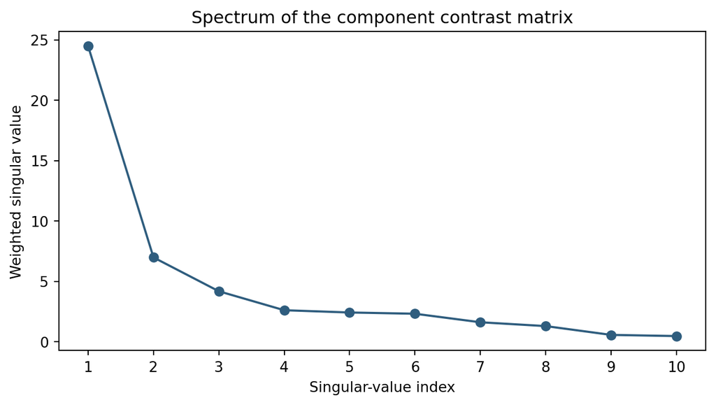

```python
fig, ax = plt.subplots(figsize=(7, 4))
ax.plot(np.arange(1, len(singular_values) + 1), singular_values, "o-", color="#2f5d7e")
ax.set_xlabel("Singular-value index")
ax.set_ylabel("Weighted singular value")
ax.set_title("Spectrum of the component contrast matrix")
ax.set_xticks(np.arange(1, len(singular_values) + 1))
fig.tight_layout()
```

**What this cell does.** Plots the singular values of the weighted component matrix, another view of how well the component directions are separated.

**How to interpret the result.** Zero singular values indicate rank deficiency. A wide spread between the largest and smallest values indicates an ill-conditioned design and potentially sensitive estimates.

## 5. Consistency and influence

Standardized residuals ask whether a study is poorly reproduced by the additive model. Leave-one-study-out refits ask whether one study has excessive influence on the component estimates.

| STUDY_ID | residual | standardized_residual | Q_contribution | leverage |
| --- | --- | --- | --- | --- |
| 02_Aragones_2012 | 0.009 | 0.026 | 0.000 | 0.815 |
| 04_Bekelman_2018 | -0.004 | -0.026 | 0.000 | 0.957 |
| 05_Bekelman_2015 | 0.261 | 0.462 | 0.069 | 0.679 |
| 10_Fletcher_2021a | -0.003 | -0.026 | 0.000 | 0.939 |
| 11_Fletcher_2021b | -0.002 | -0.026 | 0.000 | 0.965 |
| 12_Gensichen_2009 | -0.068 | -0.388 | 0.017 | 0.888 |
| 13_Hölzel_2018 | 0.006 | 0.026 | 0.000 | 0.883 |
| 22_Richards_2013 | -0.107 | -0.312 | 0.030 | 0.695 |
| 24_Rollman_2016 | -0.181 | -0.298 | 0.044 | 0.505 |
| 26_Salisbury_2016 | 0.082 | 0.468 | 0.021 | 0.904 |
| 30_Srinivasan_2022 | -0.000 | -0.026 | 0.000 | 0.999 |
| 33_Zimmerman_2016 | 0.186 | 0.462 | 0.049 | 0.771 |

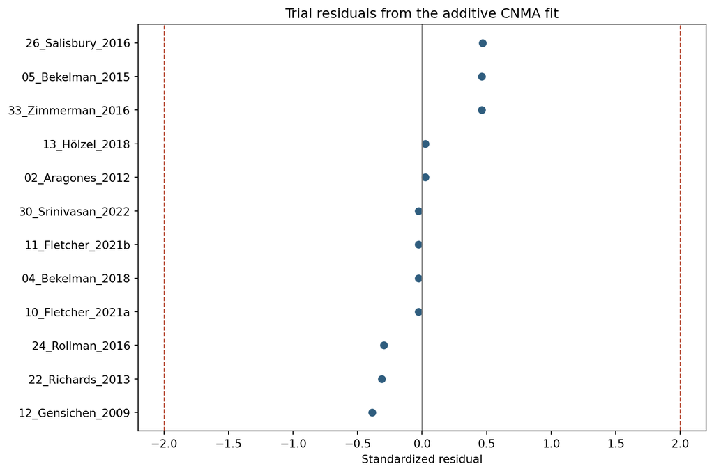

```python
weighted_design = X * np.sqrt(weights[:, None])
q_matrix, _ = np.linalg.qr(weighted_design, mode="reduced")
leverage = np.sum(q_matrix**2, axis=1)
standardized_residual = additive["residuals"] / np.sqrt(
    trial_contrasts["variance"].to_numpy() * np.maximum(1 - leverage, 1e-12)
)

residual_diagnostics = contrast_fit.copy()
residual_diagnostics["leverage"] = leverage
residual_diagnostics["standardized_residual"] = standardized_residual

plot_data = residual_diagnostics.sort_values("standardized_residual")
fig, ax = plt.subplots(figsize=(9, 6))
ax.scatter(plot_data["standardized_residual"], np.arange(len(plot_data)), color="#2f5d7e")
ax.axvline(0, color="0.5", linewidth=1)
ax.axvline(-2, color="#b4442e", linewidth=1, linestyle="--")
ax.axvline(2, color="#b4442e", linewidth=1, linestyle="--")
ax.set_yticks(np.arange(len(plot_data)), plot_data.index)
ax.set_xlabel("Standardized residual")
ax.set_title("Trial residuals from the additive CNMA fit")
fig.tight_layout()

residual_diagnostics[["residual", "standardized_residual", "Q_contribution", "leverage"]].round(3)
```

**What this cell does.** Calculates leverage and standardized residuals to find trials poorly reproduced by the additive model.

**How to interpret the result.** Standardized residuals beyond roughly ±2 flag poor fit. High leverage means that a study has unusual component information and can strongly affect the estimates even with a small residual.

```python
full_coefficients = additive["coefficients"]
loo_effect_rows = []
influence_rows = []

for omitted_index, omitted_study in enumerate(X_contrast.index):
    keep = np.arange(len(d)) != omitted_index
    omitted_rank = np.linalg.matrix_rank(X[keep])
    if omitted_rank != len(component_cols):
        influence_rows.append(
            {
                "omitted_study": omitted_study,
                "rank": omitted_rank,
                "median_absolute_shift": np.nan,
                "maximum_absolute_shift": np.nan,
            }
        )
        continue

    omitted_fit = weighted_fit(X[keep], d[keep], weights[keep])
    shifts = np.abs(omitted_fit["coefficients"] - full_coefficients)
    influence_rows.append(
        {
            "omitted_study": omitted_study,
            "rank": omitted_rank,
            "median_absolute_shift": np.median(shifts),
            "maximum_absolute_shift": np.max(shifts),
        }
    )
    loo_effect_rows.append(
        pd.DataFrame(
            {
                "omitted_study": omitted_study,
                "component": component_cols,
                "estimate": omitted_fit["coefficients"],
            }
        )
    )

leave_one_out_influence = (
    pd.DataFrame(influence_rows)
    .set_index("omitted_study")
    .sort_values("maximum_absolute_shift", ascending=False)
)
leave_one_out_effects = pd.concat(loo_effect_rows, ignore_index=True)

leave_one_out_component_stability = (
    leave_one_out_effects.groupby("component")["estimate"]
    .agg(["min", "max"])
    .reindex(component_cols)
)
leave_one_out_component_stability.insert(0, "full_data_estimate", full_coefficients)
leave_one_out_component_stability["maximum_absolute_shift"] = np.maximum(
    np.abs(
        leave_one_out_component_stability["min"]
        - leave_one_out_component_stability["full_data_estimate"]
    ),
    np.abs(
        leave_one_out_component_stability["max"]
        - leave_one_out_component_stability["full_data_estimate"]
    ),
)
leave_one_out_component_stability.index = leave_one_out_component_stability.index.map(
    COMPONENT_LABELS
)

display(leave_one_out_influence.round(3), leave_one_out_component_stability.round(3))
```

| omitted_study | rank | median_absolute_shift | maximum_absolute_shift |
| --- | --- | --- | --- |
| 12_Gensichen_2009 | 10 | 0.328 | 0.788 |
| 26_Salisbury_2016 | 10 | 0.402 | 0.787 |
| 33_Zimmerman_2016 | 10 | 0.300 | 0.535 |
| 05_Bekelman_2015 | 10 | 0.210 | 0.356 |
| 24_Rollman_2016 | 10 | 0.164 | 0.266 |
| 22_Richards_2013 | 10 | 0.066 | 0.205 |
| 30_Srinivasan_2022 | 10 | 0.031 | 0.095 |
| 04_Bekelman_2018 | 10 | 0.014 | 0.050 |
| 02_Aragones_2012 | 10 | 0.010 | 0.046 |
| 13_Hölzel_2018 | 10 | 0.011 | 0.044 |
| 11_Fletcher_2021b | 10 | 0.007 | 0.036 |
| 10_Fletcher_2021a | 10 | 0.007 | 0.034 |

| component | full_data_estimate | min | max | maximum_absolute_shift |
| --- | --- | --- | --- | --- |
| Specialist involvement | 1.337 | 0.982 | 2.124 | 0.787 |
| Psychological treatment | -1.922 | -2.173 | -1.763 | 0.251 |
| Goal setting | 4.335 | 4.086 | 4.902 | 0.567 |
| Patient preference considered | -3.554 | -4.156 | -3.373 | 0.603 |
| Automated follow-up | -1.691 | -2.078 | -1.177 | 0.514 |
| Regular patient review | 2.867 | 2.353 | 3.654 | 0.788 |
| Coping strategies | -1.775 | -2.016 | -1.606 | 0.241 |
| Relapse prevention plan | -2.185 | -2.884 | -2.063 | 0.699 |
| Family and friends involved | -1.681 | -1.970 | -1.159 | 0.522 |
| Community or cultural context | -1.979 | -2.514 | -1.703 | 0.535 |

**What this cell does.** Refits the unregularized additive model after omitting one study at a time and records changes in every component estimate.

**How to interpret the result.** Rank should remain full after omitting each study. Large changes in component estimates identify influential studies and conclusions that depend heavily on individual trials.

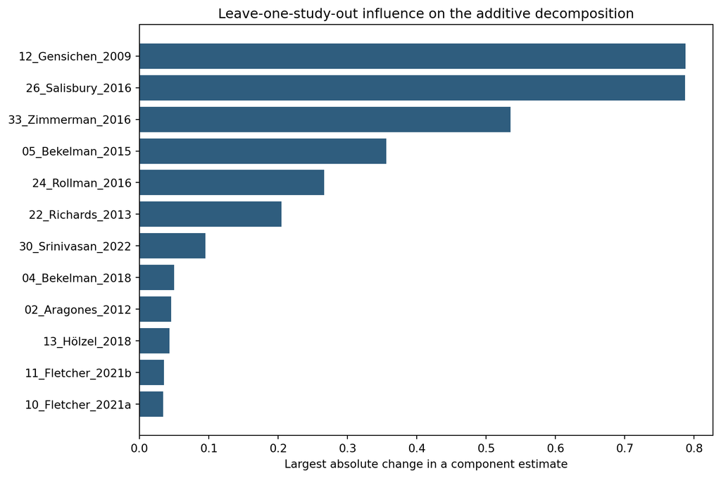

```python
plot_data = leave_one_out_influence.iloc[::-1]
fig, ax = plt.subplots(figsize=(9, 6))
ax.barh(plot_data.index, plot_data["maximum_absolute_shift"], color="#2f5d7e")
ax.set_xlabel("Largest absolute change in a component estimate")
ax.set_title("Leave-one-study-out influence on the additive decomposition")
fig.tight_layout()
```

**What this cell does.** Plots the maximum component-estimate change caused by removing each study.

**How to interpret the result.** Longer bars indicate studies whose removal changes at least one component estimate more strongly.

## 6. Summary

```python
maximum_residual = float(np.max(np.abs(standardized_residual)))
maximum_loo_shift = float(leave_one_out_influence["maximum_absolute_shift"].max())
transitivity_flag_count = len(transitivity_flags)

assumption_summary = pd.DataFrame(
    [
        {
            "assumption": "Global additivity",
            "diagnostic": f"Q={additive['Q']:.3f}, df={additive['df']}, p={additive['p_value']:.3f}",
            "assessment": "No lack of fit detected, but power is limited by only 2 residual df.",
        },
        {
            "assumption": "Transitivity",
            "diagnostic": f"{transitivity_flag_count} modifier-component correlations with |r| >= 0.60",
            "assessment": "Potential imbalance requires substantive review; setting was unavailable.",
        },
        {
            "assumption": "Rank / identifiability",
            "diagnostic": (
                f"rank={np.linalg.matrix_rank(X)}/{X.shape[1]}, "
                f"weighted condition number={np.linalg.cond(X * np.sqrt(weights[:, None])):.1f}"
            ),
            "assessment": "Full rank and robust to omitting one study, but the design is not strongly conditioned.",
        },
        {
            "assumption": "Trial-level consistency",
            "diagnostic": (
                f"maximum |standardized residual|={maximum_residual:.2f}; "
                f"maximum leave-one-out shift={maximum_loo_shift:.2f} PHQ-9"
            ),
            "assessment": "No outlying residuals; some component estimates remain study-sensitive.",
        },
    ]
).set_index("assumption")

assumption_summary
```

| assumption | diagnostic | assessment |
| --- | --- | --- |
| Global additivity | Q=0.229, df=2, p=0.892 | No lack of fit detected, but power is limited ... |
| Transitivity | 2 modifier-component correlations with \|r\| >= ... | Potential imbalance requires substantive revie... |
| Rank / identifiability | rank=10/10, weighted condition number=51.9 | Full rank and robust to omitting one study, bu... |
| Trial-level consistency | maximum \|standardized residual\|=0.47; maximum ... | No outlying residuals; some component estimate... |

**What this cell does.** Collects the main assumption checks into one concise results table.

**How to interpret the result.** Read the checks together: a pass means that a problem was not detected, not that the assumption is proven. Warnings should be carried into the limitations and interpretation.

## 7. Export

```python
EXPORT_DIR.mkdir(parents=True, exist_ok=True)

trial_contrasts.to_csv(EXPORT_DIR / "trial_contrasts.csv")
additive_fit.to_csv(EXPORT_DIR / "global_additivity_fit.csv", header=True)
contrast_fit.to_csv(EXPORT_DIR / "additive_trial_fit.csv")
trial_characteristics.to_csv(EXPORT_DIR / "trial_characteristics.csv")
transitivity_correlations.to_csv(EXPORT_DIR / "transitivity_correlations.csv")
transitivity_flags.to_csv(EXPORT_DIR / "transitivity_flags.csv")
design_diagnostics.to_csv(EXPORT_DIR / "design_diagnostics.csv", header=True)
residual_diagnostics.to_csv(EXPORT_DIR / "trial_residual_diagnostics.csv")
leave_one_out_influence.to_csv(EXPORT_DIR / "leave_one_out_study_influence.csv")
leave_one_out_component_stability.to_csv(
    EXPORT_DIR / "leave_one_out_component_stability.csv"
)
assumption_summary.to_csv(EXPORT_DIR / "assumption_summary.csv")

manifest = {
    "analysis": "PATH-CNMA assumption checks",
    "source_report": "reports/Step-2_CNMA.html",
    "reference": (
        "Rücker G, Schmitz S, Schwarzer G. Component network meta-analysis compared "
        "to a matching method in a disconnected network: A case study. "
        "Biometrical Journal. 2021;63:447-461."
    ),
    "component_interactions_fitted": False,
    "n_patients": int(len(model_df)),
    "n_studies": int(model_df["STUDY_ID"].nunique()),
    "n_components": len(component_cols),
    "global_additivity_Q": additive["Q"],
    "global_additivity_df": int(additive["df"]),
    "global_additivity_p_value": additive["p_value"],
    "transitivity_limitations": [
        "Only 12 studies",
        "Setting unavailable",
        "Follow-up month constant after cohort restriction",
        "Publication year parsed from the study identifier",
    ],
}
with (EXPORT_DIR / "manifest.json").open("w") as file:
    json.dump(manifest, file, indent=2)

print(f"Exported assumption checks to {EXPORT_DIR}")
```

```
Exported assumption checks to /Users/jan/Work/LMU/dssg-2026/collaborative-care-analysis/reports/exports/path_cnma_assumption_checks
```

**What this cell does.** Writes the trial contrasts, assumption diagnostics, influence analyses, summary table, and metadata to disk.

**How to interpret the result.** A printed export path confirms that the diagnostics were written. Check the summary and manifest before sharing them.